# The normal distribution

In this lab, you’ll investigate the probability distribution that is most central to statistics: the normal distribution. If you are confident that your data are nearly normal, that opens the door to many powerful statistical methods. Here we’ll use the graphical tools of R to assess the normality of our data and also learn how to generate random numbers from a normal distribution.

## Getting Started

### Load packages

In this lab, we will explore and visualize the data using the **tidyverse** suite of packages as well as the **openintro** package.

Let’s load the packages.

```r
library(tidyverse)
library(openintro)
```

### The data

This week you’ll be working with fast food data. This data set contains data on 515 menu items from some of the most popular fast food restaurants worldwide. Let’s take a quick peek at the first few rows of the data.

Either you can use `glimpse` like before, or `head` to do this.

```r
library(tidyverse)
library(openintro)
head(fastfood)
```

```
## # A tibble: 6 x 17
##   restaurant item       calories cal_fat total_fat sat_fat trans_fat cholesterol
##   <chr>      <chr>         <dbl>   <dbl>     <dbl>   <dbl>     <dbl>       <dbl>
## 1 Mcdonalds  Artisan G~      380      60         7       2       0            95
## 2 Mcdonalds  Single Ba~      840     410        45      17       1.5         130
## 3 Mcdonalds  Double Ba~     1130     600        67      27       3           220
## 4 Mcdonalds  Grilled B~      750     280        31      10       0.5         155
## 5 Mcdonalds  Crispy Ba~      920     410        45      12       0.5         120
## 6 Mcdonalds  Big Mac         540     250        28      10       1            80
## # ... with 9 more variables: sodium <dbl>, total_carb <dbl>, fiber <dbl>,
## #   sugar <dbl>, protein <dbl>, vit_a <dbl>, vit_c <dbl>, calcium <dbl>,
## #   salad <chr>
```

You’ll see that for every observation there are 17 measurements, many of which are nutritional facts.

You’ll be focusing on just two columns to get started:calories, calories from fat.

Let’s first focus on just products from Dairy Queen.

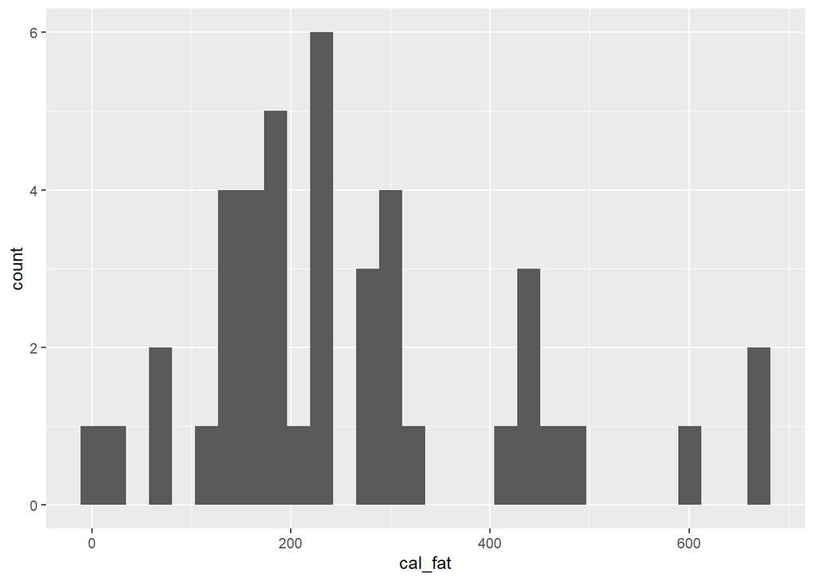

```r
dairy_queen <- fastfood %>%
  filter(restaurant == "Dairy Queen")

dairy_queen%>%
  ggplot(aes(x = cal_fat))+
  geom_histogram()
```

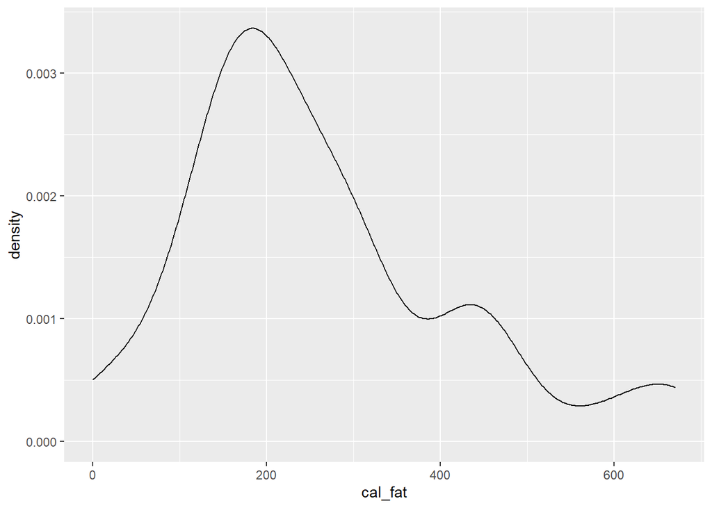

```r
dairy_queen%>%
  ggplot(aes(x = cal_fat))+
  geom_density()
```

## The normal distribution

In your description of the distributions, did you use words like *bell-shaped* or *normal*? It’s tempting to say so when faced with a unimodal symmetric distribution.

```r
dqmean <- mean(dairy_queen$cal_fat)
dqsd   <- sd(dairy_queen$cal_fat)
```

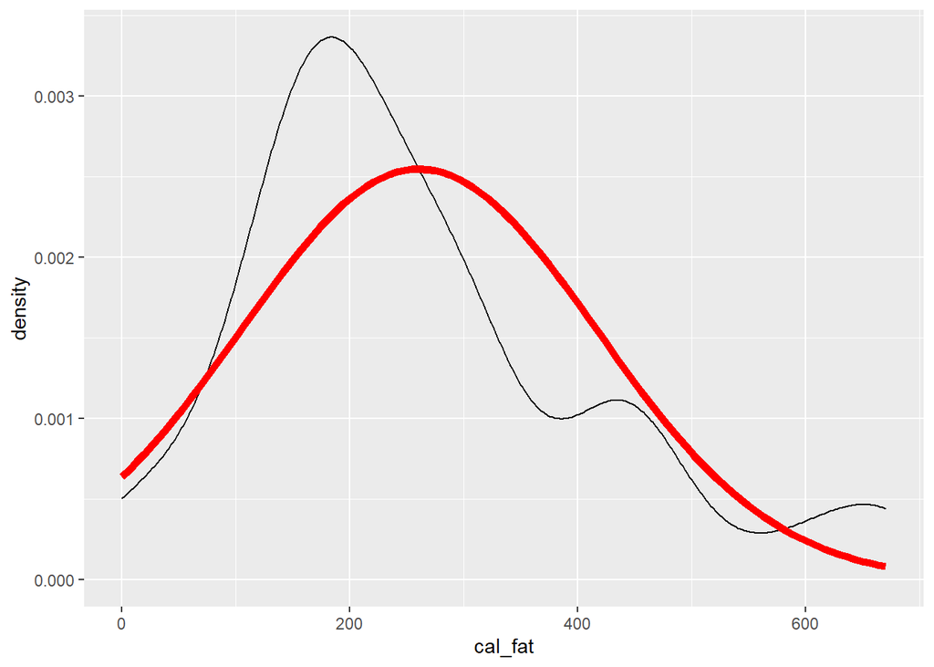

```r
ggplot(data = dairy_queen, aes(x = cal_fat)) +
        geom_blank() +
        geom_density(aes(y = ..density..)) +
        stat_function(fun = dnorm, args = c(mean = dqmean, sd = dqsd), col = "red", lwd = 2)
```

## Evaluating the normal distribution

Eyeballing the shape of the histogram is one way to determine if the data appear to be nearly normally distributed, but it can be frustrating to decide just how close the histogram is to the curve. An alternative approach involves constructing a normal probability plot, also called a normal Q-Q plot for “quantile-quantile”.

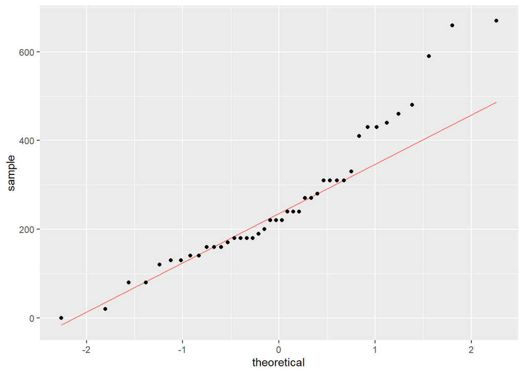

```r
ggplot(data = dairy_queen, aes(sample = cal_fat)) +
  geom_qq_line(aes(col = "red"), show.legend = F)+
  geom_qq()
```

The x-axis values correspond to the quantiles of a theoretically normal curve with mean 0 and standard deviation 1 (i.e., the standard normal distribution). The y-axis values correspond to the quantiles of the original unstandardized sample data. However, even if we were to standardize the sample data values, the Q-Q plot would look identical. A data set that is nearly normal will result in a probability plot where the points closely follow a diagonal line. Any deviations from normality leads to deviations of these points from that line.

The plot for Dairy Queen’s calories from fat shows points that tend to follow the line but with some errant points towards the upper tail. You’re left with the same problem that we encountered with the histogram above: how close is close enough?

## Finding Probability

**Properties of the Normal Distribution:** We have the following properties associated with the normal distribution. Consider $X\sim N\left(\mu, \sigma\right)$.

The area beneath the entire distribution is 1 (since this is equivalent to the probability that $X$ takes on any of its possible values).

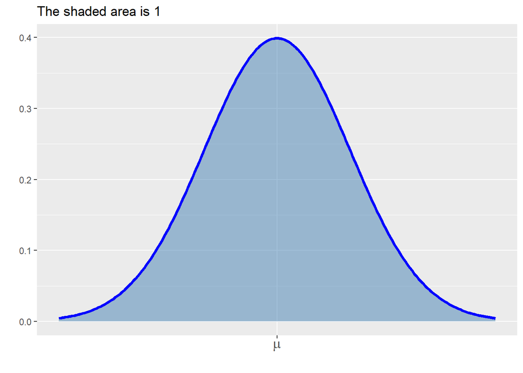

$\displaystyle{\mathbb{P}\left[X\leq \mu\right] = \mathbb{P}\left[X\geq \mu\right] = 0.5}$ (the area underneath a full half of the distribution is 0.5)

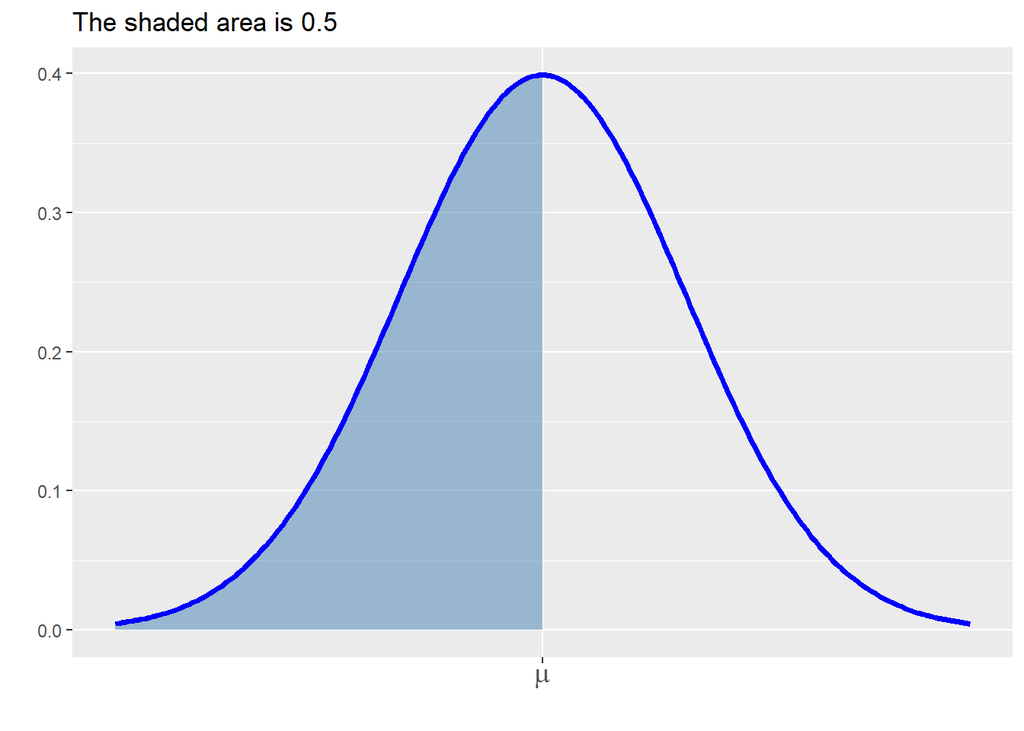

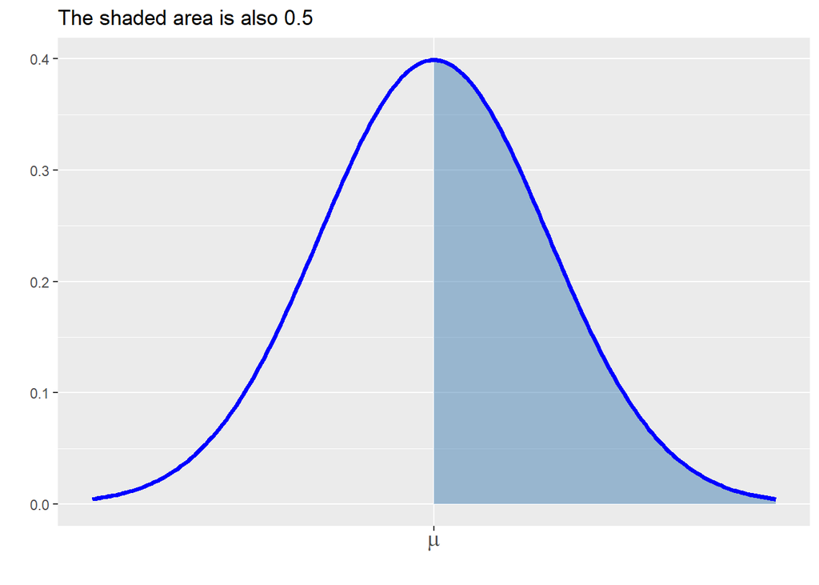

The distribution is symmetric. In symbols, $\mathbb{P}\left[X\leq \mu - k\right] = \mathbb{P}\left[X \geq \mu + k\right]$ for any $k$.

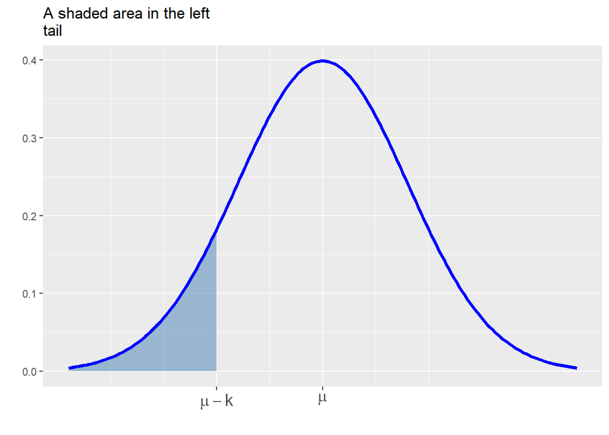

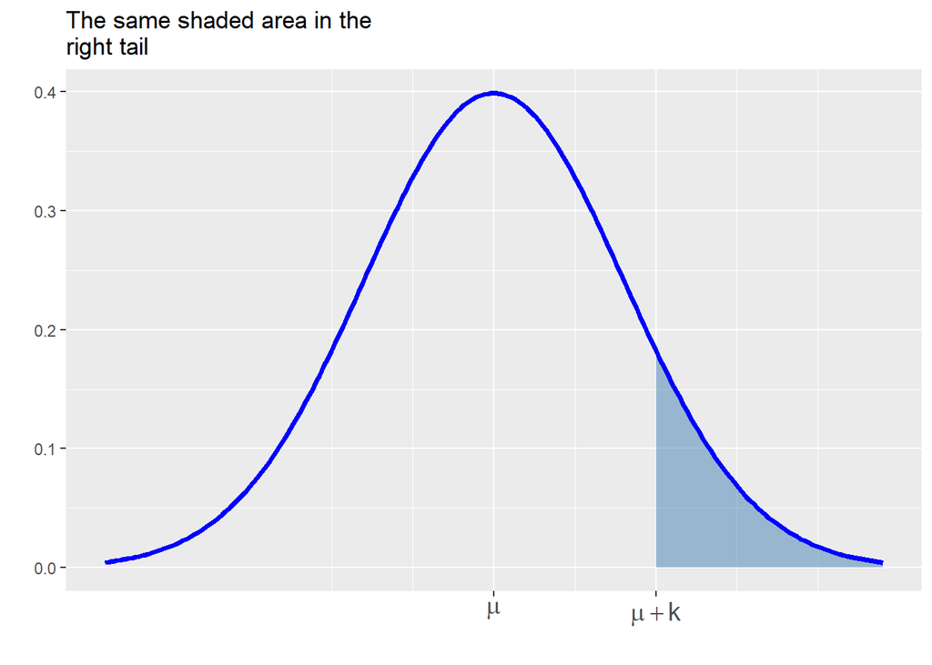

$\displaystyle{\mathbb{P}\left[X = k\right] = 0}$ (the probability that $X$ takes on any prescribed value exactly is $0$)

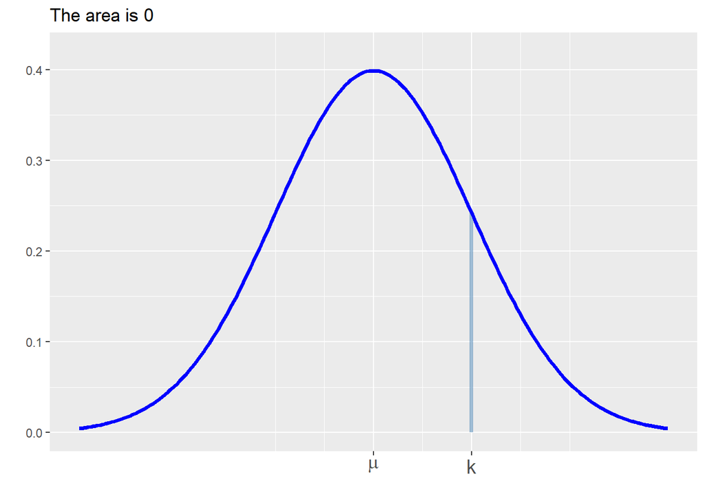

We can use a similar technique for Normal Distribution from Binomial Distribution of `pbinom()` to acquire the sum of probability of events for a certain number of successes and less than those for a given n. For normal distribution, we will make use of the function `pnorm()`.

Let’s find the area under the curve for the given plot.

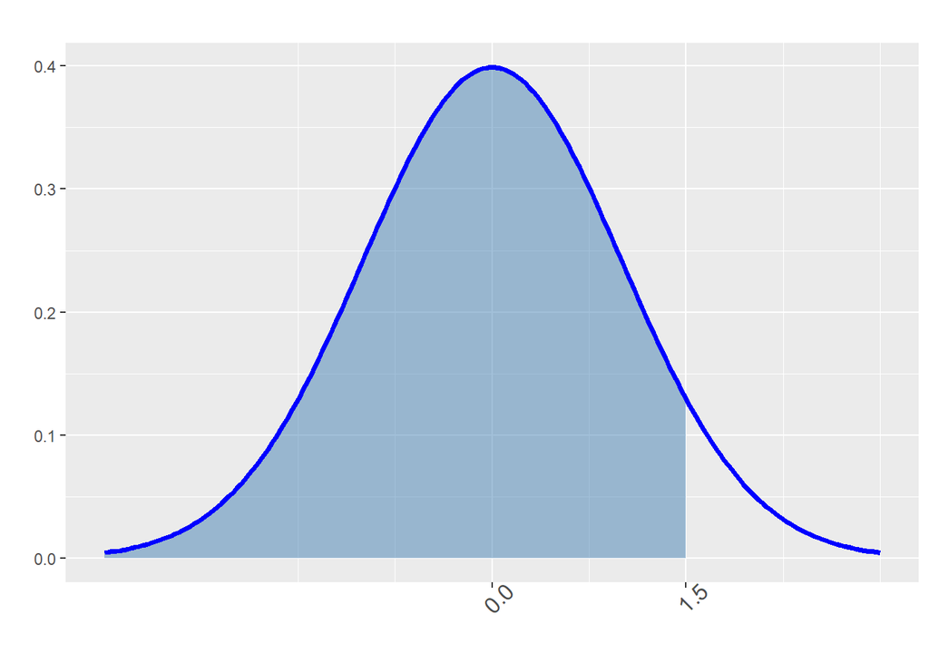

So to find this area, we will use the following R code:

```r
pnorm(1.5, mean = 0, sd = 1)
```

```
## [1] 0.9331928
```

Now, let’s use this function to find the following areas:

1. Find the area under the curve of the following plot:

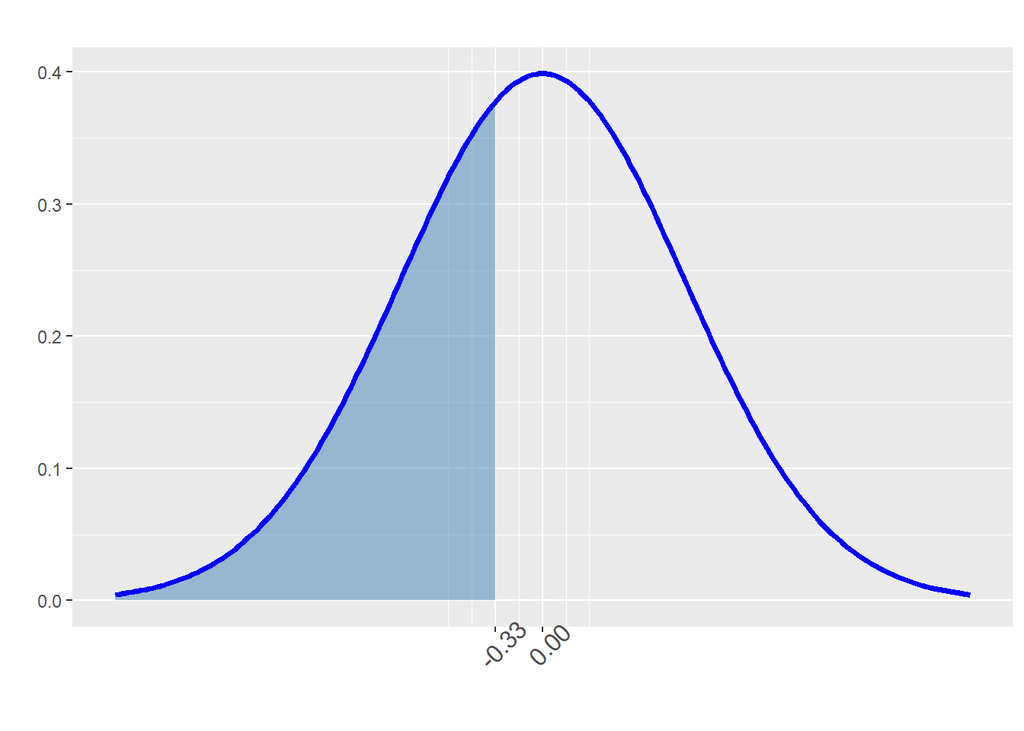

2. Find the are under the curve for $\mathbb{P}\left[-1.89 < Z < 1.89\right]$

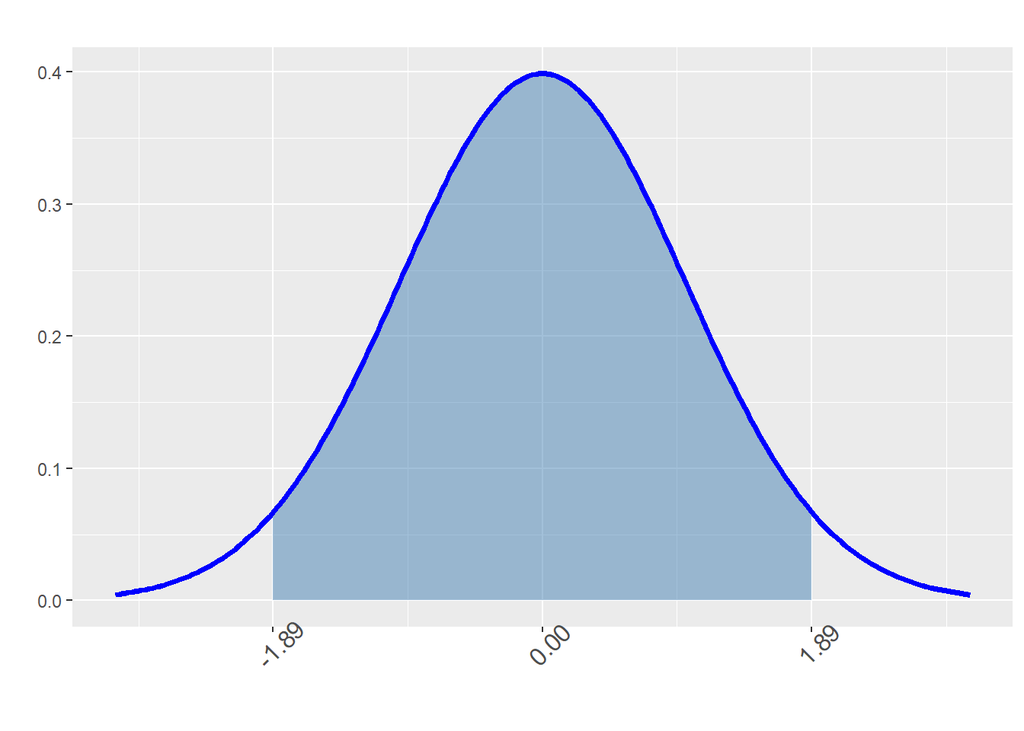

Let’s consider this situation. The average daily high temperature in June in LA is 77$^{\circ}$F with a standard deviation of 5$^{\circ}$F. Suppose that the temperatures in June closely follow a normal distribution.

3. What is the probability of observing an 83$^{\circ}$F temperature or higher in LA during a randomly chosen day in June?

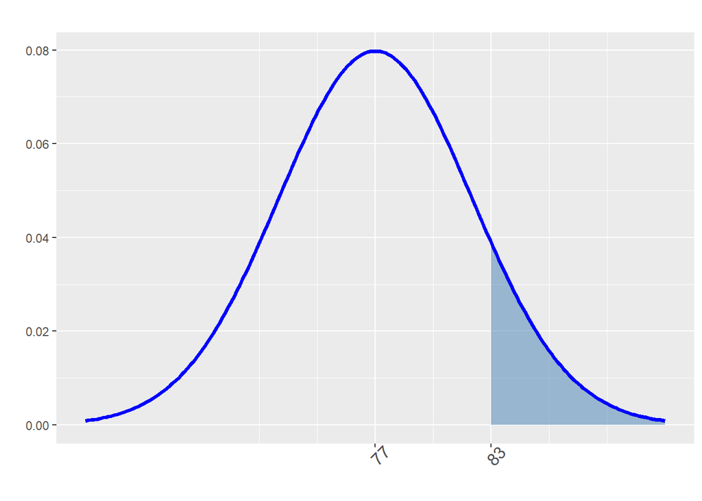

So, we can use a value, mean and sd to find the area under the curve. But we can use area under the curve, mean and sd to find the exact value as well. To do so we will make use of `qnorm(p, mean, sd)`

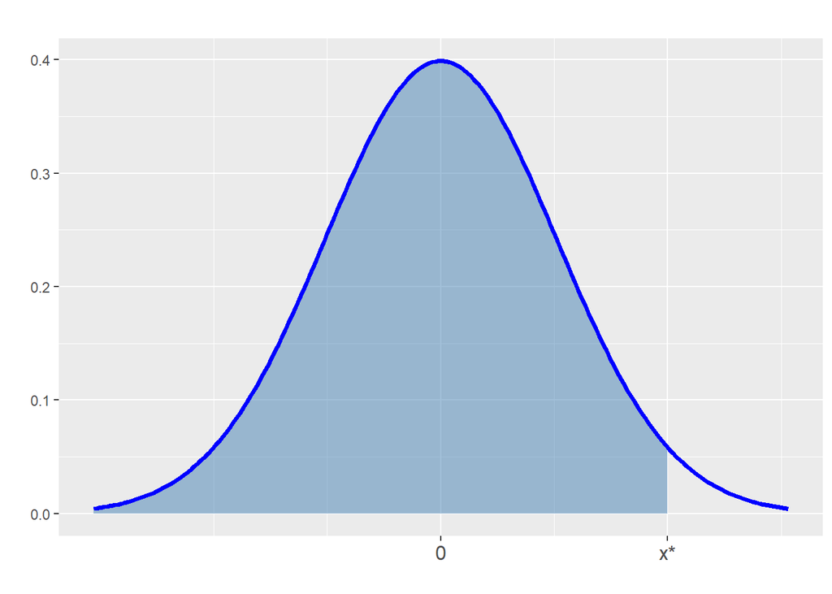

Let’s say for instance, "x*" is 1.96 on the standard normal curve. Then the area under the curve would be

```r
pnorm(1.96, mean = 0, sd = 1)
```

```
## [1] 0.9750021
```

Now, if we use this number in `qnorm()` then we will get "x*" in return. That is,

```r
qnorm(0.9750, mean = 0, sd = 1)
```

```
## [1] 1.959964
```

We tend to round the Z-score to two decimal places. So the outcome would be 1.96.

Using this principle let’s answer the following exercises using the example from earlier.

4. How cool are the coldest 10% of the days (days with lowest average high temperature) during June in LA?

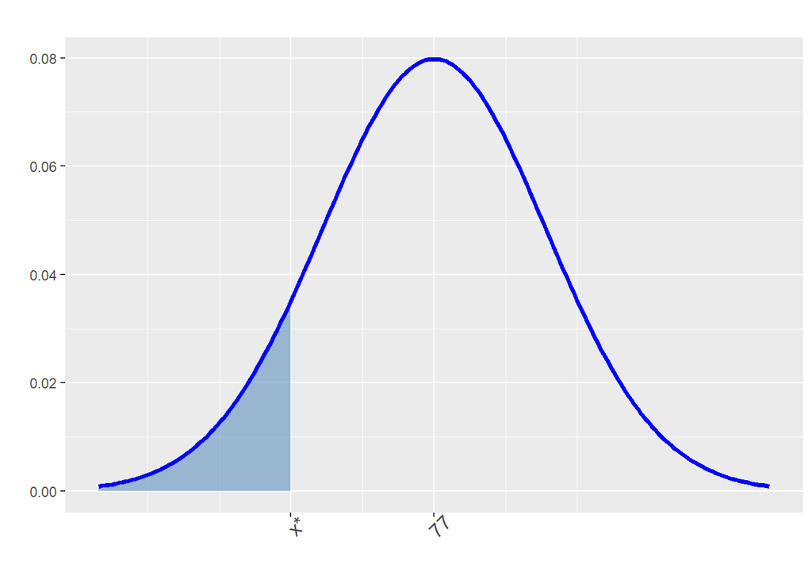

5. How hot are the hottest 5% of the days (days with highest average high temperature) during June in LA?

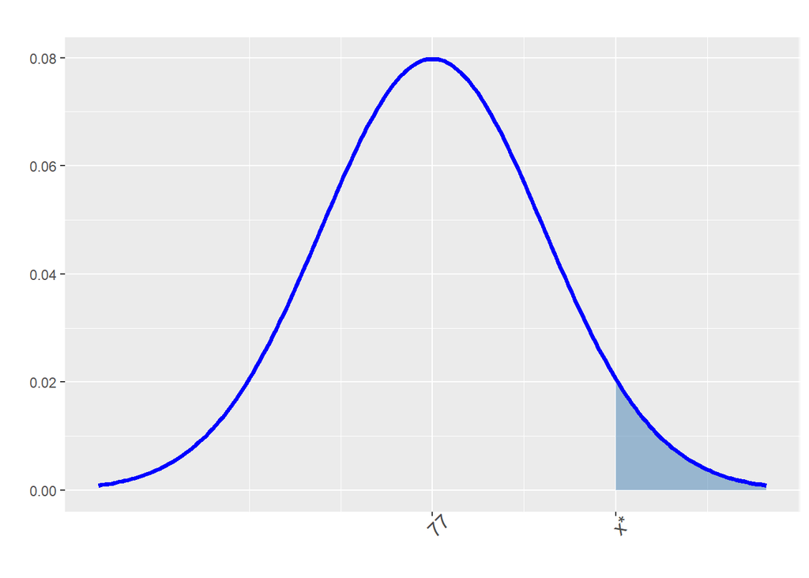